# Marcos de cambio climático en medios noticiosos el Golfo de California

#### Hem Nalini Morzaria-Luna. CEDO Intercultural

#### Gabriela Cruz-Piñón. Departamento de Ciencias Marinas y Costeras. Universidad Autónoma de Baja California Sur.

#### Andrea K. Gerlak. School of Geography and Development. Associate Research Professor

#### Luis E. Calderón-Aguilera. Departamento de Ecología Marina. Centro de Investigación Científica y de Educación Superior de Ensenada

#### Peggy Turk-Boyer. CEDO Intercultural

El marco o presentación de los artículos que describen el cambio climático puede afectar la respuesta a variaciones en condiciones locales y la aceptación de políticas de adaptación. Los medios noticiosos pueden influir en la interpretación que los habitantes de las comunidades costeras, como los pescadores y otros usuarios de recursos, tienen del cambio climático al legitimar perspectivas específicas ideológicas o de política pública, al atribuir responsabilidad, comunicar incertidumbre científica y enfatizar el papel de instituciones locales.

Nuestro proyecto analiza cómo los medios nacionales, regionales y locales comunican el cambio climático en la región que rodea el Golfo de California. Nos enfocamos en medios que solo tienen presencia electrónica y en medios que tienen versión electrónica e impresa.

Desarrollamos una base de datos con todos los artículos publicados por fuentes noticiosas en los estados de Sonora, Sinaloa, Nayarit, Jalisco, Baja California, y Baja California Sur entre 01/01/2016 and 12/31/2017 y que están archivados en línea, así como fuentes noticiosas nacionales. Extrajimos artículos basados en las palabras claves “cambio climático”“,”acidificación del océano”, “Acuerdo de París” (Paris accord), y “protocolo de Kyoto” (Kyoto protocol)

```r
print(head(html.list))
```

```
## # A tibble: 6 x 4
##   NOMBRE_DEL_PERIOD… LINK_NOTA                             FECHA   ARTICULO
##   <chr>              <chr>                                 <chr>   <chr>
## 1 EL IMPARCIAL       http://www.elimparcial.com/EdicionEn… 12/5/2… <NA>
## 2 EL IMPARCIAL       http://www.elimparcial.com/EdicionEn… 11/16/… <NA>
## 3 EL IMPARCIAL       http://www.elimparcial.com/EdicionEn… 11/4/2… <NA>
## 4 EL IMPARCIAL       http://www.elimparcial.com/EdicionEn… 10/15/… <NA>
## 5 EL IMPARCIAL       http://www.elimparcial.com/EdicionEn… 10/10/… <NA>
## 6 EL IMPARCIAL       http://www.elimparcial.com/EdicionEn… 9/21/2… <NA>
```

Este es un análisis preliminar con ~1700 artículos de una muestra de 5 fuentes noticiosas locales, regionales, y nacionales, aplicado a artículos publicados entre 2016-2017. En el análisis final incluiremos un número mayor de fuentes noticiosas y más años. Inicialmente separamos cada artículo en las palabras que los componen, después eliminamos las conjunciones y las palabras comunes. Inicialmente analizamos la frecuencia de palabras en el conjunto de artículos.

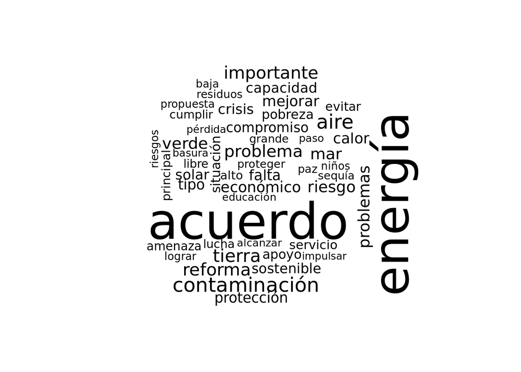

En esta nube de palabras, mayor tamaño indica que la palabra es más frecuente.

### Análisis de sentimiento

Despues, realizamos un analisis de sentimiento, que es el proceso que determina el tono emocional que hay detrás de palabras determinadas, si en general el articulo contiene una opinión positiva o negativa sobre el tema

```r
print(head(word.tbl))
```

```
## # A tibble: 6 x 6
##   NOMBRE_DEL_PERIO… LINK_NOTA             FECHA article_num word   category
##   <chr>             <chr>                 <chr>       <int> <chr>  <chr>
## 1 EXPRESO           http://www.expreso.c… 11/1…           1 aspir… positivo
## 2 EXPRESO           http://www.expreso.c… 11/1…           1 tierra negativo
## 3 EXPRESO           http://www.expreso.c… 11/1…           1 garan… positivo
## 4 EXPRESO           http://www.expreso.c… 11/1…           1 impor… positivo
## 5 EXPRESO           http://www.expreso.c… 11/1…           1 soste… positivo
## 6 EXPRESO           http://www.expreso.c… 11/1…           1 acuer… positivo
```

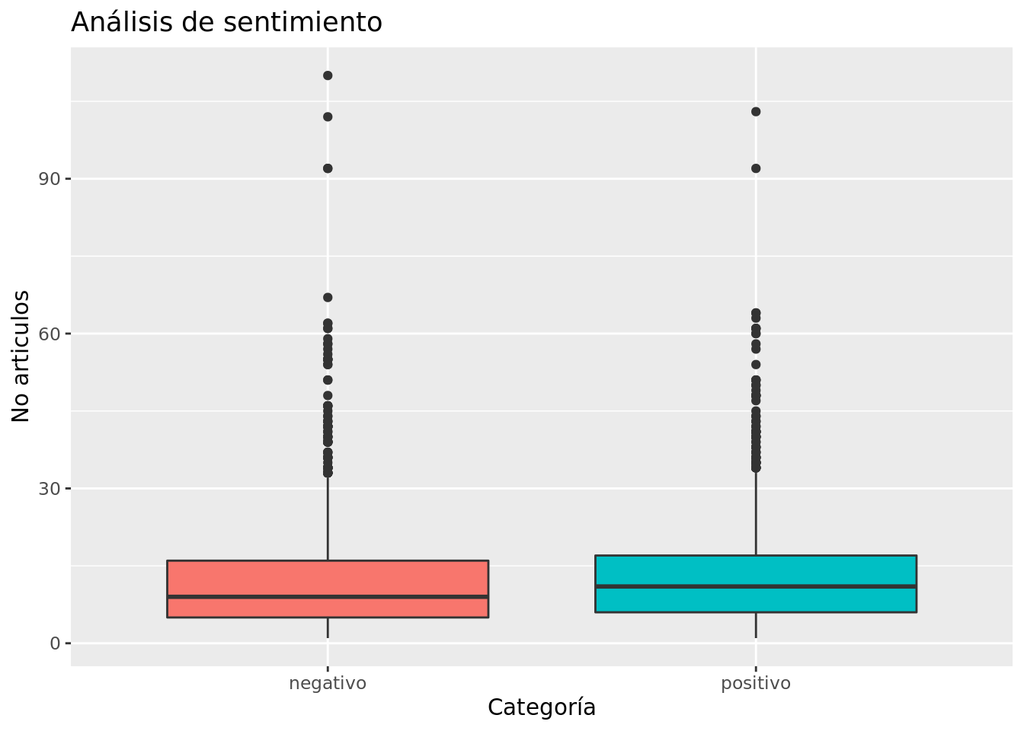

Esta gráfica muestra la frecuencia de palabras asignadas como positivas y negativas.

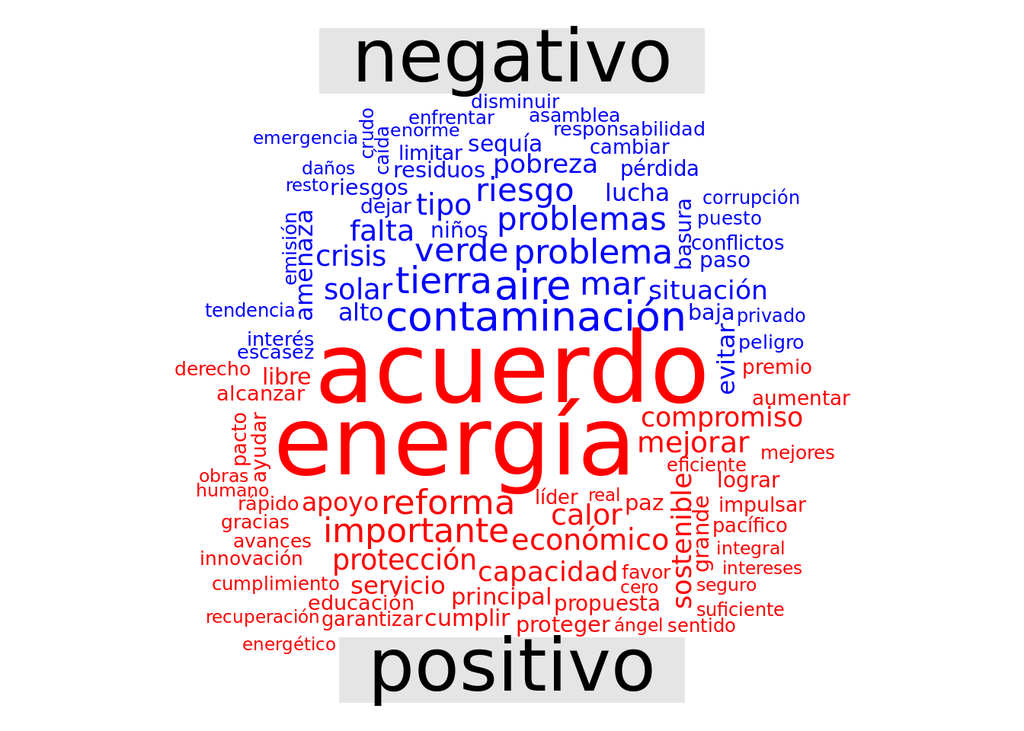

Nube de sentimientos, indica las palabras más comunes con connotación negativa y positiva en el conjunto de fuentes noticiosas.

### Modelaje de temas

Finalmente aplicamos un análisis de modelaje de temas o tópicos al cuerpo del texto. Utilizamos aprendizaje de máquinas no supervisado, en una técnica llamada Asignación Latente de Dirichlet, donde nos basamos en la co-ocurrencia de palabras y no proveemos nada de información respecto a cómo se deben de clasificar los artículos ni ninguna interpretación para identificar los conjuntos de palabras que pueden ser interpretados como marcos.

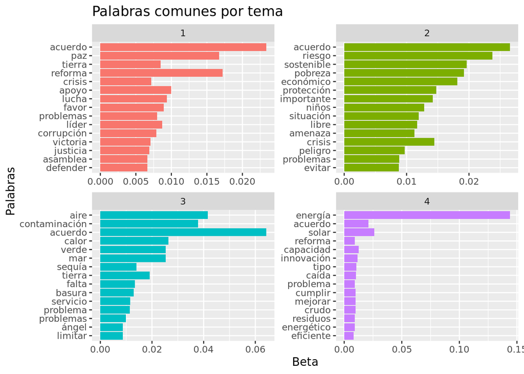

```r
climate.top.terms %>%
  mutate(term=reorder(term, beta)) %>%
  ggplot(aes(term,beta, fill = factor(topic)))+
  geom_col(show.legend = FALSE)+
  facet_wrap(~ topic, scales = "free")+
  coord_flip()+
  ggtitle("Palabras comunes por tema") +
  xlab("Palabras") +
  ylab("Beta")+
  labs(fill = "Tema")
```